# Face Generation

In this project, you'll define and train a DCGAN on a dataset of faces. Your goal is to get a generator network to generate *new* images of faces that look as realistic as possible!

The project will be broken down into a series of tasks from **loading in data to defining and training adversarial networks**. At the end of the notebook, you'll be able to visualize the results of your trained Generator to see how it performs; your generated samples should look like fairly realistic faces with small amounts of noise.

### Get the Data

You'll be using the [CelebFaces Attributes Dataset (CelebA)](http://mmlab.ie.cuhk.edu.hk/projects/CelebA.html) to train your adversarial networks.

This dataset is more complex than the number datasets (like MNIST or SVHN) you've been working with, and so, you should prepare to define deeper networks and train them for a longer time to get good results. It is suggested that you utilize a GPU for training.

### Pre-processed Data

Since the project's main focus is on building the GANs, we've done *some* of the pre-processing for you. Each of the CelebA images has been cropped to remove parts of the image that don't include a face, then resized down to 64x64x3 NumPy images. Some sample data is show below.

[figure not shown]

> If you are working locally, you can download this data [by clicking here](https://s3.amazonaws.com/video.udacity-data.com/topher/2018/November/5be7eb6f_processed-celeba-small/processed-celeba-small.zip)

This is a zip file that you'll need to extract in the home directory of this notebook for further loading and processing. After extracting the data, you should be left with a directory of data `processed_celeba_small/`

```python
# can comment out after executing
!unzip processed_celeba_small.zip
```

```python
data_dir = 'processed_celeba_small/'

"""
DON'T MODIFY ANYTHING IN THIS CELL
"""
import pickle as pkl
import matplotlib.pyplot as plt
import numpy as np
import problem_unittests as tests
#import helper

%matplotlib inline
```

## Visualize the CelebA Data

### Pre-process and Load the Data

Since the project's main focus is on building the GANs, we've done *some* of the pre-processing for you. Each of the CelebA images has been cropped to remove parts of the image that don't include a face, then resized down to 64x64x3 NumPy images. This *pre-processed* dataset is a smaller subset of the very large CelebA data.

> There are a few other steps that you'll need to **transform** this data and create a **DataLoader**.

#### Exercise: Complete the following `get_dataloader` function, such that it satisfies these requirements:

- Your images should be square, Tensor images of size `image_size x image_size` in the x and y dimension.
- Your function should return a DataLoader that shuffles and batches these Tensor images.

#### ImageFolder

To create a dataset given a directory of images, it's recommended that you use PyTorch's [ImageFolder](https://pytorch.org/docs/stable/torchvision/datasets.html#imagefolder) wrapper, with a root directory `processed_celeba_small/` and data transformation passed in.

```python
# necessary imports
import torch
from torchvision import datasets
from torchvision import transforms
```

```python
def get_dataloader(batch_size, image_size, data_dir='processed_celeba_small/'):
    """
    Batch the neural network data using DataLoader
    :param batch_size: The size of each batch; the number of images in a batch
    :param img_size: The square size of the image data (x, y)
    :param data_dir: Directory where image data is located
    :return: DataLoader with batched data
    """

    # TODO: Implement function and return a dataloader

    transform = transforms.Compose([
        transforms.Resize(size=(image_size, img_size)),
        transforms.ToTensor()
    ])

    data = datasets.ImageFolder(root=data_dir, transform=transform)
    data_loader = torch.utils.data.DataLoader(dataset=data, batch_size=batch_size, shuffle=True, pin_memory=True)

    return data_loader
```

## Create a DataLoader

#### Exercise: Create a DataLoader `celeba_train_loader` with appropriate hyperparameters.

Call the above function and create a dataloader to view images.

- You can decide on any reasonable `batch_size` parameter
- Your `image_size` **must be** `32`. Resizing the data to a smaller size will make for faster training, while still creating convincing images of faces!

```python
# Define function hyperparameters
batch_size = 128
img_size = 32

"""
DON'T MODIFY ANYTHING IN THIS CELL THAT IS BELOW THIS LINE
"""
# Call your function and get a dataloader
celeba_train_loader = get_dataloader(batch_size, img_size)
```

```python
print("Number of train loader images: {}".format(len(celeba_train_loader.dataset)))
print("Number of batches: {}".format(len(celeba_train_loader)))
```

```
Number of train loader images: 89931
Number of batches: 703
```

Next, you can view some images! You should seen square images of somewhat-centered faces.

Note: You'll need to convert the Tensor images into a NumPy type and transpose the dimensions to correctly display an image, suggested `imshow` code is below, but it may not be perfect.

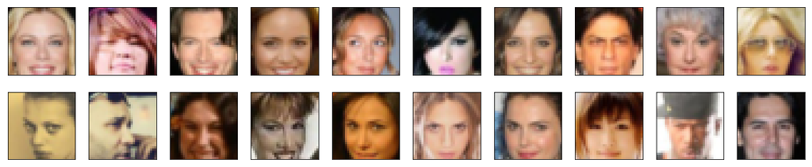

```python
# helper display function
def imshow(img):
    npimg = img.numpy()
    plt.imshow(np.transpose(npimg, (1, 2, 0)))

"""
DON'T MODIFY ANYTHING IN THIS CELL THAT IS BELOW THIS LINE
"""
# obtain one batch of training images
dataiter = iter(celeba_train_loader)
images, _ = dataiter.next() # _ for no labels

# make sure images are scaled to (0, 1)
images = (images - images.min()) / (images.max() - images.min())

# plot the images in the batch, along with the corresponding labels
fig = plt.figure(figsize=(20, 4))
plot_size=20
for idx in np.arange(plot_size):
    ax = fig.add_subplot(2, plot_size/2, idx+1, xticks=[], yticks=[])
    imshow(images[idx])
```

#### Exercise: Pre-process your image data and scale it to a pixel range of -1 to 1

You need to do a bit of pre-processing; you know that the output of a `tanh` activated generator will contain pixel values in a range from -1 to 1, and so, we need to rescale our training images to a range of -1 to 1. (Right now, they are in a range from 0-1.)

```python
# TODO: Complete the scale function
def scale(x, feature_range=(-1, 1)):
    ''' Scale takes in an image x in any scale and returns that image,
    scaled with a feature_range of pixel values from -1 to 1.'''
    # scale to feature_range and return scaled x
    x = 2 * (x - x.min()) / (x.max() - x.min()) - 1

    return x
```

```python
"""
DON'T MODIFY ANYTHING IN THIS CELL THAT IS BELOW THIS LINE
"""
# check scaled range
# should be close to -1 to 1
img = images[0]
scaled_img = scale(img)

print('Min: ', scaled_img.min())
print('Max: ', scaled_img.max())
```

```
Min:  tensor(-1.)
Max:  tensor(1.)
```

# Define the Model

A GAN is comprised of two adversarial networks, a discriminator and a generator.

## Discriminator

Your first task will be to define the discriminator. This is a convolutional classifier like you've built before, only without any maxpooling layers. To deal with this complex data, it's suggested you use a deep network with **normalization**. You are also allowed to create any helper functions that may be useful.

#### Exercise: Complete the Discriminator class

- The inputs to the discriminator are 32x32x3 tensor images
- The output should be a single value that will indicate whether a given image is real or fake

```python
import torch.nn as nn
import torch.nn.functional as F
import collections
```

```python
class Discriminator(nn.Module):

    def __init__(self, conv_dim=32):
        """
        Initialize the Discriminator Module
        :param conv_dim: The depth of the first convolutional layer
        """
        super(Discriminator, self).__init__()

        # complete init function
        self.conv_dim = conv_dim

        ## Define downsampler
        self.features = nn.Sequential(collections.OrderedDict([
            ('conv1', nn.Conv2d(in_channels=3, out_channels=conv_dim*4,
                                kernel_size=4, stride=2, padding=1, bias=True)),
            ('leakyrelu1', nn.LeakyReLU(negative_slope=0.2, inplace=True)),
            ('conv2', nn.Conv2d(in_channels=conv_dim*4, out_channels=conv_dim*8,
                                kernel_size=4, stride=2, padding=1, bias=False)),
            ('batchnorm1', nn.BatchNorm2d(num_features=conv_dim*8)),
            ('leakyrelu2', nn.LeakyReLU(negative_slope=0.2, inplace=True)),
            ('conv3', nn.Conv2d(in_channels=conv_dim*8, out_channels=conv_dim*16,
                                kernel_size=4, stride=2, padding=1, bias=False)),
            ('batchnorm2', nn.BatchNorm2d(num_features=conv_dim*16)),
            ('leakyrelu3', nn.LeakyReLU(negative_slope=0.2, inplace=True))
        ]))

        self.classifier = nn.Sequential(collections.OrderedDict([
            ('fc', nn.Linear(in_features=conv_dim*16*4*4, out_features=1, bias=True))
        ]))


    def forward(self, x):
        """
        Forward propagation of the neural network
        :param x: The input to the neural network
        :return: Discriminator logits; the output of the neural network
        """
        # define feedforward behavior

        x = self.features(x)
        x = x.view(-1, self.conv_dim*16*4*4) # flatten feature vector prior to entering classifier
        x = self.classifier(x)

        return x

"""
DON'T MODIFY ANYTHING IN THIS CELL THAT IS BELOW THIS LINE
"""
tests.test_discriminator(Discriminator)
```

```
Tests Passed
```

## Generator

The generator should upsample an input and generate a *new* image of the same size as our training data `32x32x3`. This should be mostly transpose convolutional layers with normalization applied to the outputs.

#### Exercise: Complete the Generator class

- The inputs to the generator are vectors of some length `z_size`
- The output should be a image of shape `32x32x3`

```python
class Generator(nn.Module):

    def __init__(self, z_size, conv_dim=32):
        """
        Initialize the Generator Module
        :param z_size: The length of the input latent vector, z
        :param conv_dim: The depth of the inputs to the *last* transpose convolutional layer
        """
        super(Generator, self).__init__()

        # complete init function

        self.conv_dim = conv_dim

        ## Define layers of a CNN
        self.vectorizer = nn.Sequential(collections.OrderedDict([
            ('fc', nn.Linear(in_features=z_size, out_features=conv_dim*16*4*4, bias=True))
        ]))

        self.upsampler = nn.Sequential(collections.OrderedDict([
            ('transpose_conv1', nn.ConvTranspose2d(in_channels=conv_dim*16, out_channels=conv_dim*8,
                                kernel_size=4, stride=2, padding=1, bias=False)),
            ('batchnorm1', nn.BatchNorm2d(num_features=conv_dim*8)),
            ('relu1', nn.ReLU(inplace=True)),
            ('transpose_conv2', nn.ConvTranspose2d(in_channels=conv_dim*8, out_channels=conv_dim*4,
                                kernel_size=4, stride=2, padding=1, bias=False)),
            ('batchnorm2', nn.BatchNorm2d(num_features=conv_dim*4)),
            ('relu2', nn.ReLU(inplace=True)),
            ('transpose_conv3', nn.ConvTranspose2d(in_channels=conv_dim*4, out_channels=3,
                                kernel_size=4, stride=2, padding=1, bias=True)),
            ('tanh', nn.Tanh())
        ]))

    def forward(self, x):
        """
        Forward propagation of the neural network
        :param x: The input to the neural network
        :return: A 32x32x3 Tensor image as output
        """
        # define feedforward behavior
        x = self.vectorizer(x)
        x = x.view(-1, self.conv_dim*16, 4, 4)
        x = self.upsampler(x)

        return x

"""
DON'T MODIFY ANYTHING IN THIS CELL THAT IS BELOW THIS LINE
"""
tests.test_generator(Generator)
```

```
Tests Passed
```

## Initialize the weights of your networks

To help your models converge, you should initialize the weights of the convolutional and linear layers in your model. From reading the [original DCGAN paper](https://arxiv.org/pdf/1511.06434.pdf), they say:

> All weights were initialized from a zero-centered Normal distribution with standard deviation 0.02.

So, your next task will be to define a weight initialization function that does just this!

You can refer back to the lesson on weight initialization or even consult existing model code, such as that from [the `networks.py` file in CycleGAN Github repository](https://github.com/junyanz/pytorch-CycleGAN-and-pix2pix/blob/master/models/networks.py) to help you complete this function.

#### Exercise: Complete the weight initialization function

- This should initialize only **convolutional** and **linear** layers
- Initialize the weights to a normal distribution, centered around 0, with a standard deviation of 0.02.
- The bias terms, if they exist, may be left alone or set to 0.

```python
def weights_init_normal(m):
    """
    Applies initial weights to certain layers in a model .
    The weights are taken from a normal distribution
    with mean = 0, std dev = 0.02.
    :param m: A module or layer in a network
    """
    # classname will be something like:
    # `Conv`, `BatchNorm2d`, `Linear`, etc.
    classname = m.__class__.__name__

    # TODO: Apply initial weights to convolutional and linear layers
    if isinstance(m, nn.Conv2d):
        nn.init.normal_(m.weight, mean=0.0, std=0.02)
    if isinstance(m, nn.Linear):
        nn.init.normal_(m.weight, mean=0.0, std=0.02)
```

## Build complete network

Define your models' hyperparameters and instantiate the discriminator and generator from the classes defined above. Make sure you've passed in the correct input arguments.

```python
"""
DON'T MODIFY ANYTHING IN THIS CELL THAT IS BELOW THIS LINE
"""
def build_network(d_conv_dim, g_conv_dim, z_size):
    # define discriminator and generator
    D = Discriminator(d_conv_dim)
    G = Generator(z_size=z_size, conv_dim=g_conv_dim)

    # initialize model weights
    D.apply(weights_init_normal)
    G.apply(weights_init_normal)

    print(D)
    print()
    print(G)

    return D, G
```

#### Exercise: Define model hyperparameters

```python
# Define model hyperparams
d_conv_dim = 32
g_conv_dim = 32
z_size = 128

"""
DON'T MODIFY ANYTHING IN THIS CELL THAT IS BELOW THIS LINE
"""
D, G = build_network(d_conv_dim, g_conv_dim, z_size)
```

```
Discriminator(
  (features): Sequential(
    (conv1): Conv2d(3, 128, kernel_size=(4, 4), stride=(2, 2), padding=(1, 1))
    (leakyrelu1): LeakyReLU(negative_slope=0.2, inplace)
    (conv2): Conv2d(128, 256, kernel_size=(4, 4), stride=(2, 2), padding=(1, 1), bias=False)
    (batchnorm1): BatchNorm2d(256, eps=1e-05, momentum=0.1, affine=True, track_running_stats=True)
    (leakyrelu2): LeakyReLU(negative_slope=0.2, inplace)
    (conv3): Conv2d(256, 512, kernel_size=(4, 4), stride=(2, 2), padding=(1, 1), bias=False)
    (batchnorm2): BatchNorm2d(512, eps=1e-05, momentum=0.1, affine=True, track_running_stats=True)
    (leakyrelu3): LeakyReLU(negative_slope=0.2, inplace)
  )
  (classifier): Sequential(
    (fc): Linear(in_features=8192, out_features=1, bias=True)
  )
)

Generator(
  (vectorizer): Sequential(
    (fc): Linear(in_features=128, out_features=8192, bias=True)
  )
  (upsampler): Sequential(
    (transpose_conv1): ConvTranspose2d(512, 256, kernel_size=(4, 4), stride=(2, 2), padding=(1, 1), bias=False)
    (batchnorm1): BatchNorm2d(256, eps=1e-05, momentum=0.1, affine=True, track_running_stats=True)
    (relu1): ReLU(inplace)
    (transpose_conv2): ConvTranspose2d(256, 128, kernel_size=(4, 4), stride=(2, 2), padding=(1, 1), bias=False)
    (batchnorm2): BatchNorm2d(128, eps=1e-05, momentum=0.1, affine=True, track_running_stats=True)
    (relu2): ReLU(inplace)
    (transpose_conv3): ConvTranspose2d(128, 3, kernel_size=(4, 4), stride=(2, 2), padding=(1, 1))
    (tanh): Tanh()
  )
)
```

### Training on GPU

Check if you can train on GPU. Here, we'll set this as a boolean variable `train_on_gpu`. Later, you'll be responsible for making sure that

> - Models,
> - Model inputs, and
> - Loss function arguments

Are moved to GPU, where appropriate.

```python
"""
DON'T MODIFY ANYTHING IN THIS CELL
"""
import torch

# Check for a GPU
train_on_gpu = torch.cuda.is_available()
if not train_on_gpu:
    print('No GPU found. Please use a GPU to train your neural network.')
else:
    print('Training on GPU!')
```

```
Training on GPU!
```

## Discriminator and Generator Losses

Now we need to calculate the losses for both types of adversarial networks.

### Discriminator Losses

> - For the discriminator, the total loss is the sum of the losses for real and fake images, `d_loss = d_real_loss + d_fake_loss`.
> - Remember that we want the discriminator to output 1 for real images and 0 for fake images, so we need to set up the losses to reflect that.

### Generator Loss

The generator loss will look similar only with flipped labels. The generator's goal is to get the discriminator to *think* its generated images are *real*.

#### Exercise: Complete real and fake loss functions

**You may choose to use either cross entropy or a least squares error loss to complete the following `real_loss` and `fake_loss` functions.**

```python
def real_loss(D_out, smooth=False):
    '''Calculates how close discriminator outputs are to being real.
       param, D_out: discriminator logits
       return: real loss'''
    batch_size = D_out.size(0)
    if smooth:
        labels = torch.ones(batch_size) * 0.9
    else:
        labels = torch.ones(batch_size)
    # move labels to GPU if available
    if train_on_gpu:
        labels = labels.cuda()
    # binary cross entropy with logits loss
    criterion = nn.BCEWithLogitsLoss()
    # calculate loss
    loss = criterion(D_out.squeeze(), labels)
    return loss

def fake_loss(D_out):
    '''Calculates how close discriminator outputs are to being fake.
       param, D_out: discriminator logits
       return: fake loss'''
    batch_size = D_out.size(0)
    labels = torch.zeros(batch_size)
    # move labels to GPU if available
    if train_on_gpu:
        labels = labels.cuda()
    # binary cross entropy with logits loss
    criterion = nn.BCEWithLogitsLoss()
    # calculate loss
    loss = criterion(D_out.squeeze(), labels)
    return loss
```

## Optimizers

#### Exercise: Define optimizers for your Discriminator (D) and Generator (G)

Define optimizers for your models with appropriate hyperparameters.

```python
import torch.optim as optim

# params
lr = 0.0002
beta1=0.5
beta2=0.999 # default value

# Create optimizers for the discriminator D and generator G
d_optimizer = optim.Adam(D.parameters(), lr, (beta1, beta2))
g_optimizer = optim.Adam(G.parameters(), lr, (beta1, beta2))
```

## Training

Training will involve alternating between training the discriminator and the generator. You'll use your functions `real_loss` and `fake_loss` to help you calculate the discriminator losses.

- You should train the discriminator by alternating on real and fake images
- Then the generator, which tries to trick the discriminator and should have an opposing loss function

#### Saving Samples

You've been given some code to print out some loss statistics and save some generated "fake" samples.

```python
def slerp(interpol_param, first_point, last_point):


    first_point_norm = first_point/torch.norm(first_point, dim=1, keepdim=True)
    last_point_norm = last_point/torch.norm(last_point, dim=1, keepdim=True)
    omega = torch.acos((first_point_norm*last_point_norm).sum(1))
    so = torch.sin(omega)

    if 0 in so:
        linear_interpol = (1.0-interpol_param) * first_point + interpol_param * last_point # L'Hopital's rule/LERP
        return linear_interpol

    spheric_linear_interpol = (torch.sin((1.0-interpol_param)*omega)/so).unsqueeze(1)*first_point + (torch.sin(interpol_param*omega)/so).unsqueeze(1) * last_point

    return spheric_linear_interpol
```

```python
def train(D, G, n_epochs, print_every=50):
    '''Trains adversarial networks for some number of epochs
       param, D: the discriminator network
       param, G: the generator network
       param, n_epochs: number of epochs to train for
       param, print_every: when to print and record the models' losses
       return: D and G losses'''

    # move models to GPU
    if train_on_gpu:
        D.cuda()
        G.cuda()

    # keep track of loss and generated, "fake" samples
    samples = []
    losses = []

    # Get some fixed data for sampling. These are images that are held
    # constant throughout training, and allow us to inspect the model's performance
    sample_size=16
    # each sample in the mini-batch is a point on the arc
    z_start_unscaled = torch.randn(sample_size, z_size)
    z_end_unscaled = torch.randn(sample_size, z_size)
    z_interpol_unscaled = slerp(np.random.uniform(0, 1), z_start_unscaled, z_end_unscaled)

    temp = []
    for img in range(sample_size):
        img_scaled = scale(z_interpol_unscaled[img]).unsqueeze(0)
        temp.append(img_scaled)
    fixed_z = torch.cat(temp, dim=0)
#     fixed_z = torch.FloatTensor(size=(sample_size, z_size)).uniform_(-1, 1)
    # move z to GPU if available
    if train_on_gpu:
        fixed_z = fixed_z.cuda()

    # epoch training loop
    for epoch in range(n_epochs):

        # batch training loop
        for batch_i, (real_images, _) in enumerate(celeba_train_loader):

            batch_size = real_images.size(0)
#             real_images = scale(real_images)

            # ===============================================
            #         YOUR CODE HERE: TRAIN THE NETWORKS
            # ===============================================

            # 1. Train the discriminator on real and fake images
            # Train on real images from train loader
            d_optimizer.zero_grad()

            ## add random noise to the input images and scale it to be in (-1, 1)
            real_images = real_images + noise_factor * torch.randn(*real_images.shape)
            real_images = scale(real_images)

            if train_on_gpu:
                real_images = real_images.cuda()

            D_real = D(real_images)
            d_real_loss = real_loss(D_real)

            # Train on randomly generated fake images
            z_start_unscaled = torch.randn(batch_size, z_size)
            z_end_unscaled = torch.randn(batch_size, z_size)
            z_interpol_unscaled = slerp(np.random.uniform(0, 1), z_start_unscaled, z_end_unscaled)

            temp = []
            for img in range(batch_size):
                img_scaled = scale(z_interpol_unscaled[img]).unsqueeze(0)
                temp.append(img_scaled)
            z = torch.cat(temp, dim=0)
#             z =  torch.FloatTensor(size=(batch_size, z_size)).uniform_(-1, 1)
            if train_on_gpu:
                z = z.cuda()
            fake_images = G(z)

            D_fake = D(fake_images)
            d_fake_loss = fake_loss(D_fake)
            d_loss = d_real_loss + d_fake_loss

            d_loss.backward()
            d_optimizer.step()

            # 2. Train the generator with an adversarial loss
            g_optimizer.zero_grad()

            # Train with fake images and flipped labels

            # Generate fake images
            z_start_unscaled = torch.randn(batch_size, z_size)
            z_end_unscaled = torch.randn(batch_size, z_size)
            z_interpol_unscaled = slerp(np.random.uniform(0, 1), z_start_unscaled, z_end_unscaled)

            temp = []
            for img in range(batch_size):
                img_scaled = scale(z_interpol_unscaled[img]).unsqueeze(0)
                temp.append(img_scaled)
            z = torch.cat(temp, dim=0)
#             z =  torch.FloatTensor(size=(batch_size, z_size)).uniform_(-1, 1)
            if train_on_gpu:
                z = z.cuda()
            fake_images = G(z)

            # Compute the discriminator losses on fake images
            # using flipped labels!
            D_fake = D(fake_images)
            g_loss = real_loss(D_fake) # use real loss to flip labels

            # perform backprop
            g_loss.backward()
            g_optimizer.step()

            # ===============================================
            #              END OF YOUR CODE
            # ===============================================

            # Print some loss stats
            if batch_i % print_every == 0:
                # append discriminator loss and generator loss
                losses.append((d_loss.item(), g_loss.item()))
                # print discriminator and generator loss
                print('Epoch [{:5d}/{:5d}] | d_loss: {:6.4f} | g_loss: {:6.4f}'.format(
                        epoch+1, n_epochs, d_loss.item(), g_loss.item()))


        ## AFTER EACH EPOCH##
        # this code assumes your generator is named G, feel free to change the name
        # generate and save sample, fake images
        G.eval() # for generating samples
        samples_z = G(fixed_z)
        samples.append(samples_z)
        G.train() # back to training mode

    # Save training generator samples
    with open('train_samples.pkl', 'wb') as f:
        pkl.dump(samples, f)

    # finally return losses
    return losses
```

Set your number of training epochs and train your GAN!

```python
import signal

from contextlib import contextmanager

import requests


DELAY = INTERVAL = 4 * 60  # interval time in seconds
MIN_DELAY = MIN_INTERVAL = 2 * 60
KEEPALIVE_URL = "https://nebula.udacity.com/api/v1/remote/keep-alive"
TOKEN_URL = "http://metadata.google.internal/computeMetadata/v1/instance/attributes/keep_alive_token"
TOKEN_HEADERS = {"Metadata-Flavor":"Google"}


def _request_handler(headers):
    def _handler(signum, frame):
        requests.request("POST", KEEPALIVE_URL, headers=headers)
    return _handler


@contextmanager
def active_session(delay=DELAY, interval=INTERVAL):
    """
    Example:

    from workspace_utils import active_session

    with active_session():
        # do long-running work here
    """
    token = requests.request("GET", TOKEN_URL, headers=TOKEN_HEADERS).text
    headers = {'Authorization': "STAR " + token}
    delay = max(delay, MIN_DELAY)
    interval = max(interval, MIN_INTERVAL)
    original_handler = signal.getsignal(signal.SIGALRM)
    try:
        signal.signal(signal.SIGALRM, _request_handler(headers))
        signal.setitimer(signal.ITIMER_REAL, delay, interval)
        yield
    finally:
        signal.signal(signal.SIGALRM, original_handler)
        signal.setitimer(signal.ITIMER_REAL, 0)
```

```python
# set number of epochs
n_epochs =30
noise_factor = 0.5


"""
DON'T MODIFY ANYTHING IN THIS CELL
"""
# call training function
with active_session():
    losses = train(D, G, n_epochs=n_epochs)
```

```
Epoch [    1/   30] | d_loss: 1.6155 | g_loss: 0.2503
Epoch [    1/   30] | d_loss: 0.9253 | g_loss: 3.5338
Epoch [    1/   30] | d_loss: 0.5432 | g_loss: 3.4723
Epoch [    1/   30] | d_loss: 0.5063 | g_loss: 2.3346
Epoch [    1/   30] | d_loss: 0.4393 | g_loss: 3.6296
Epoch [    1/   30] | d_loss: 0.3374 | g_loss: 3.1755
Epoch [    1/   30] | d_loss: 0.3481 | g_loss: 4.0286
Epoch [    1/   30] | d_loss: 0.6691 | g_loss: 5.3813
Epoch [    1/   30] | d_loss: 0.4200 | g_loss: 3.8950
Epoch [    1/   30] | d_loss: 0.5613 | g_loss: 4.9834
Epoch [    1/   30] | d_loss: 0.4281 | g_loss: 3.9198
Epoch [    1/   30] | d_loss: 0.6486 | g_loss: 5.2575
Epoch [    1/   30] | d_loss: 0.8245 | g_loss: 7.2697
Epoch [    1/   30] | d_loss: 0.7148 | g_loss: 3.3597
Epoch [    1/   30] | d_loss: 0.4479 | g_loss: 4.2629
Epoch [    2/   30] | d_loss: 0.5094 | g_loss: 2.9757
Epoch [    2/   30] | d_loss: 0.6668 | g_loss: 4.3885
Epoch [    2/   30] | d_loss: 0.5579 | g_loss: 3.9319
Epoch [    2/   30] | d_loss: 0.6160 | g_loss: 3.2971
Epoch [    2/   30] | d_loss: 0.7567 | g_loss: 4.5783
Epoch [    2/   30] | d_loss: 0.9451 | g_loss: 5.4243
Epoch [    2/   30] | d_loss: 0.8228 | g_loss: 4.6619
Epoch [    2/   30] | d_loss: 0.6451 | g_loss: 3.6158
Epoch [    2/   30] | d_loss: 0.8316 | g_loss: 2.9717
Epoch [    2/   30] | d_loss: 0.7310 | g_loss: 2.4623
Epoch [    2/   30] | d_loss: 0.7356 | g_loss: 2.3003
Epoch [    2/   30] | d_loss: 0.9151 | g_loss: 3.3421
Epoch [    2/   30] | d_loss: 1.0107 | g_loss: 1.6627
Epoch [    2/   30] | d_loss: 0.8218 | g_loss: 2.7429
Epoch [    2/   30] | d_loss: 0.8979 | g_loss: 2.3586
Epoch [    3/   30] | d_loss: 0.9363 | g_loss: 2.6554
Epoch [    3/   30] | d_loss: 1.0148 | g_loss: 1.7396
Epoch [    3/   30] | d_loss: 0.9588 | g_loss: 1.9955
Epoch [    3/   30] | d_loss: 0.9372 | g_loss: 1.9688
Epoch [    3/   30] | d_loss: 1.0324 | g_loss: 1.8686
Epoch [    3/   30] | d_loss: 1.0186 | g_loss: 1.7054
Epoch [    3/   30] | d_loss: 1.2142 | g_loss: 1.0555
Epoch [    3/   30] | d_loss: 1.0259 | g_loss: 1.4882
Epoch [    3/   30] | d_loss: 1.1204 | g_loss: 1.6977
Epoch [    3/   30] | d_loss: 1.1975 | g_loss: 1.1555
```

[output cut: 395 more lines]

```
Epoch [   30/   30] | d_loss: 1.4012 | g_loss: 0.8019
Epoch [   30/   30] | d_loss: 1.3863 | g_loss: 0.6951
Epoch [   30/   30] | d_loss: 1.3882 | g_loss: 0.6995
Epoch [   30/   30] | d_loss: 1.3925 | g_loss: 0.6380
Epoch [   30/   30] | d_loss: 1.3867 | g_loss: 0.6655
Epoch [   30/   30] | d_loss: 1.3881 | g_loss: 0.6954
Epoch [   30/   30] | d_loss: 1.3878 | g_loss: 0.6947
Epoch [   30/   30] | d_loss: 1.3935 | g_loss: 0.7707
Epoch [   30/   30] | d_loss: 1.3866 | g_loss: 0.6785
Epoch [   30/   30] | d_loss: 1.3925 | g_loss: 0.7516
Epoch [   30/   30] | d_loss: 1.3875 | g_loss: 0.7419
Epoch [   30/   30] | d_loss: 1.3869 | g_loss: 0.6986
Epoch [   30/   30] | d_loss: 1.4055 | g_loss: 0.5598
Epoch [   30/   30] | d_loss: 1.3884 | g_loss: 0.7151
Epoch [   30/   30] | d_loss: 1.3887 | g_loss: 0.7000
```

## Training loss

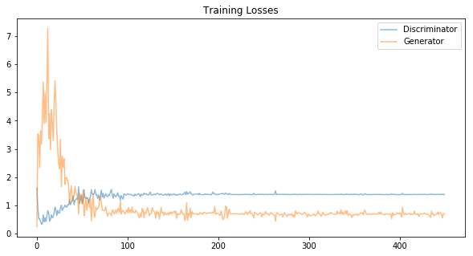

```python
fig, ax = plt.subplots(figsize=(10,5))
losses = np.array(losses)
plt.plot(losses.T[0], label='Discriminator', alpha=0.5)
plt.plot(losses.T[1], label='Generator', alpha=0.5)
plt.title("Training Losses")
plt.legend()
```

## Generator samples from training

```python
# helper function for viewing a list of passed in sample images
def view_samples(epoch, samples):
    fig, axes = plt.subplots(figsize=(16,4), nrows=2, ncols=8, sharey=True, sharex=True)
    for ax, img in zip(axes.flatten(), samples[epoch]):
        img = img.detach().cpu().numpy()
        img = np.transpose(img, (1, 2, 0))
        img = ((img + 1)*255 / (2)).astype(np.uint8)
        ax.xaxis.set_visible(False)
        ax.yaxis.set_visible(False)
        im = ax.imshow(img.reshape((32,32,3)))
```

```python
# Load samples from generator, taken while training
with open('train_samples.pkl', 'rb') as f:
    samples = pkl.load(f)
```

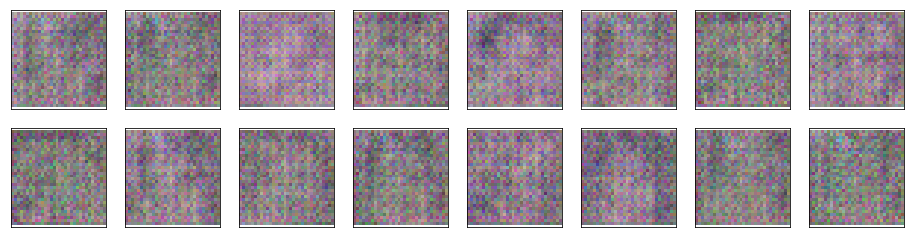

```python
_ = view_samples(-1, samples)
```